# Week 13：正则化回归与变量筛选

**主题**：`Ridge`、`Lasso`、`Elastic Net`

**本节课主线**：

- 为什么 OLS 在某些场景下不够稳？
- `loss + penalty` 如何改变模型性格？
- 为什么 `Ridge`、`Lasso`、`Elastic Net` 会走出不同的系数路径？
- 为什么模型选择不能只看图，还要看交叉验证结果？

**使用说明**：

- 本 notebook 以 `week13_class.py` 为 source of truth；
- 课堂结构按“看图提问 → 运行代码 → 总结判断”组织；
- 当前版本先搭建课堂骨架，后续再继续细化数据、图像与脚本。

## Prologue：为什么我们还要继续折腾线性模型？

上节课我们讲了 Bias-Variance Trade-off。 如果借用“开车”的比喻：

- Bias 高，像车开不快；
- Variance 高，像车开不稳；
- 真正想要的是：又快又稳；
- 最终还得去没见过的赛道上看表现，也就是泛化能力。

这节课我们继续以线性模型为例，不是因为它最强，而是因为它足够透明。 正因为透明，我们才能看见：

- OLS 在某些场景下为什么会不稳定；
- penalty 如何改变模型；
- 为什么不同正则化方法会给出不同的变量行为。

## 第一幕：OLS 还不够——为什么模型需要“约束”？

这一幕只做一件事： **先接受一个判断：在相关特征存在时，OLS 的结论可能不够稳。**

如果你要把一个回归模型交给业务团队长期使用，你更担心哪一件事？

1. 训练误差还不够低；
2. 换一批样本后，模型系数和结论明显变化。

先不要运行代码，先凭直觉选一个。

**本幕主图**：OLS 系数不稳定图

这张图要回答：

> 同一个建模任务里，只要样本略有变化，OLS 的系数会不会明显波动？

这里用“多次切分下的 OLS 系数波动”来把“不稳定”直接画出来。

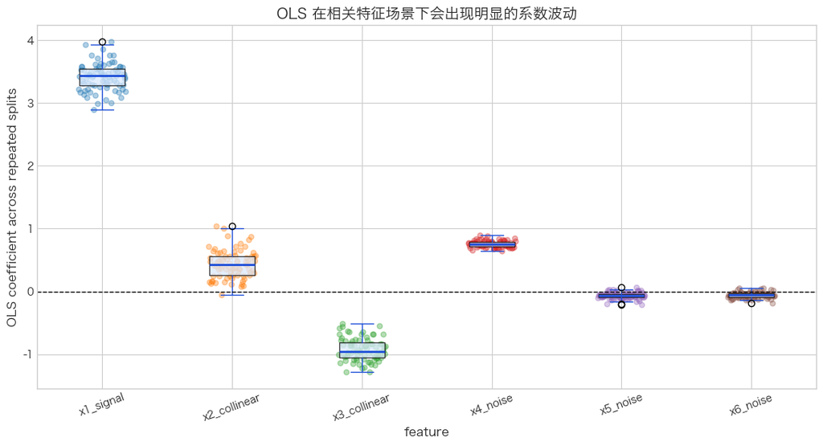

OLS 的问题不是“完全不能用”，而是：

- 当特征相关、样本扰动存在时，系数可能明显波动；
- 这意味着训练集上拟合得不错，并不代表模型结论足够稳定；
- 所以今天我们要讨论的，不是“换一个完全不同的模型”，而是“怎样给模型加约束”。

## 第二幕：统一框架——`loss + penalty`

这一幕要建立一个统一语言： **正则化不是另起炉灶，而是在原来的拟合目标里，显式加入复杂度成本。**

如果我们已经能最小化误差，为什么还要故意给模型“加限制”？

你愿不愿意为了更稳，牺牲一点训练集上的贴合度？

**本幕主图**：`loss + penalty` 的结构图

这张图要回答：

> penalty 到底在干什么？

这里用一张板书式结构图，把 `loss` 和 `penalty` 的职责拆开。

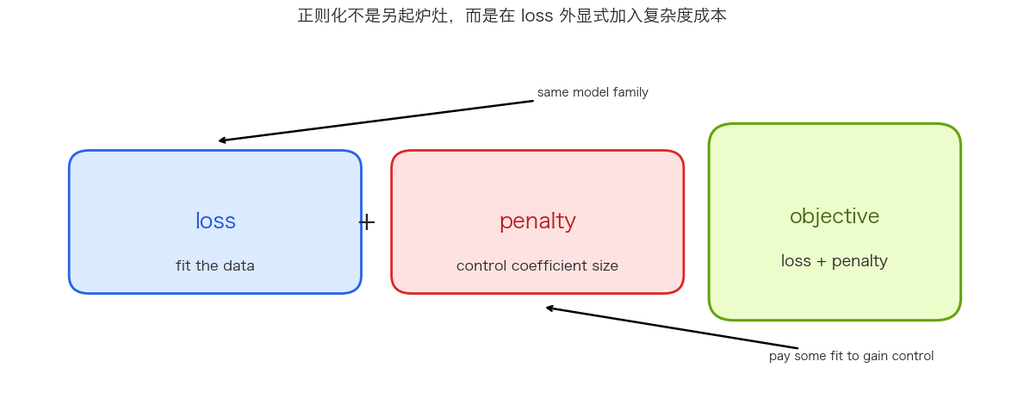

正则化回归的共同语言是：

`objective = loss + penalty`

这意味着：

- `loss` 负责拟合数据；
- `penalty` 负责约束复杂度；
- 后面三种方法的真正差异，不在于“是不是回归”，而在于“怎样约束系数”。

## 第三幕：Ridge vs Lasso——同样收缩，为什么一个保留全部、一个开始筛选？

这是全节课最重要的视觉对比幕。 主图负责展示系数路径差异，辅图负责把路径变化连接回 bias-variance / 稳定性主线。

看图之前先猜：

如果我们不断增大 penalty，下面两种现象你觉得哪一个更可能出现？

1. 所有变量一起慢慢缩小；
2. 有些变量会被直接“挤出场”。

你觉得这两种行为，对业务上的“变量名单”意味着什么不同？

**本幕主图**：`Ridge` 与 `Lasso` 的 regularization path 并排对比图

这张图要回答：

> 同样都是 penalty，为什么一个更像“整体收缩”，另一个更像“变量筛选”？

这里直接并排展示：

- `Ridge` regularization path；
- `Lasso` regularization path；
- 并保留一组强相关特征，为后续 `Elastic Net` 铺垫。

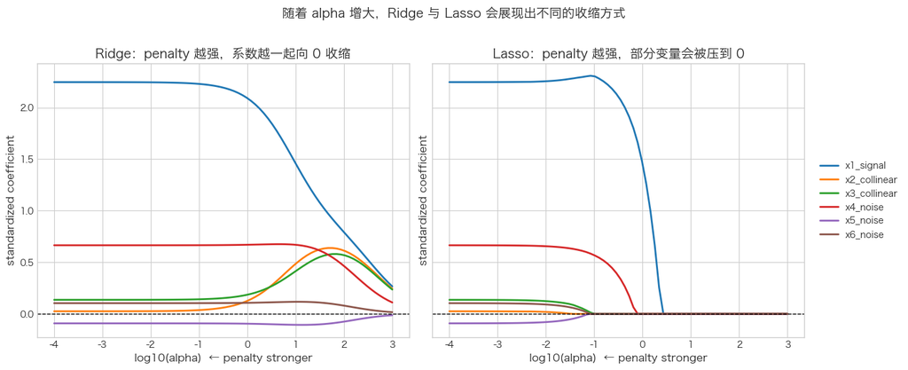

**本幕辅图**：Bias-Variance 权衡中的动图或稳定性辅助图

这张辅图要回答：

> 当 penalty 逐渐变大时，我们到底是怎样换来更稳定模型的？

这里用“系数波动 + 误差变化”的辅助图，把路径变化重新连接回“variance 下降、模型更稳”的主线。

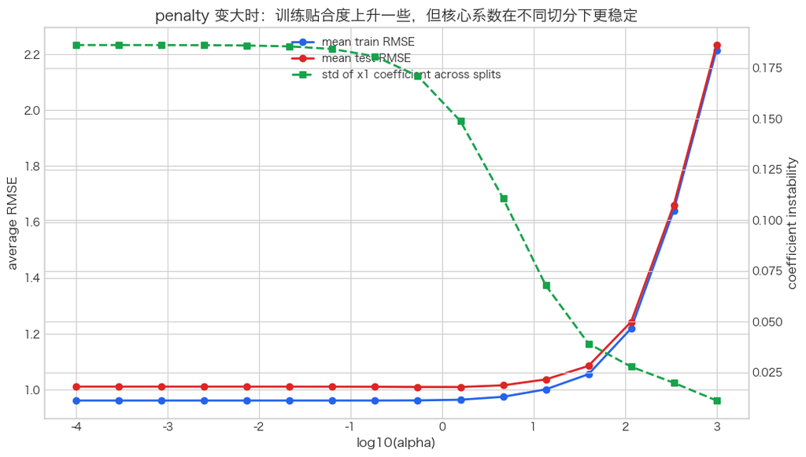

这一幕至少要收住三个判断：

- `Ridge` 的强项是稳定收缩，不是变量筛选；
- `Lasso` 的强项是稀疏与筛选，但这也意味着变量名单会变化；
- penalty 不是白加的：它的代价是牺牲一部分贴合度，换来更保守、更稳定的模型行为。

## Synthesis 1

到这里，前半节课可以被压缩成一句话：

> 正则化不是在背三个新名词，而是在同一个优化框架下，用不同 penalty 交换不同的模型性格。

## 第四幕：Elastic Net——当变量高度相关时，折中为什么更成熟？

前一幕已经看到：Ridge 更稳，Lasso 更稀疏。 但如果变量彼此相关、成组出现，问题就变成： **只留一个代表，真的总是合理吗？**

如果两列变量其实表达的是相近信息，模型只留下其中一个，你会觉得这个结果：

1. 很干脆，很好；
2. 可能有点武断。

先选一个立场，再看图。

**本幕主图**：`Lasso` 与 `Elastic Net` 在相关变量场景下的路径对比图

这张图要回答：

> 当变量成组相关时，模型是在“选一个代表”，还是“让一组变量共同保留并收缩”？

这里直接比较 `Lasso` 与 `Elastic Net` 的路径，并高亮相关变量组的行为差异。

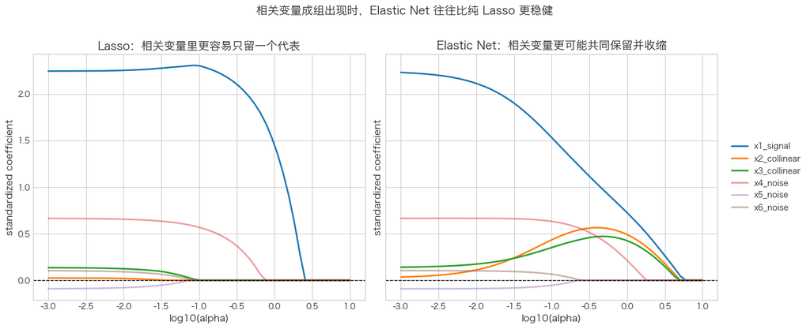

**本幕辅图**：Elastic Net 参数角色的辅助说明图或小表

这张辅图只做说明：

- 一个参数控制总体惩罚强度；
- 一个参数控制更偏向 `Lasso` 还是更偏向 `Ridge`。

|  | parameter | role | classroom_reading |
| --- | --- | --- | --- |
| 0 | alpha | 控制总体惩罚强度：越大，模型越保守 | 刹车踩多大 |
| 1 | l1_ratio | 控制更像 Lasso 还是更像 Ridge | 更想要筛选，还是更想要稳定 |

`Elastic Net` 的价值不在于“又多了一个名词”，而在于：

- 当变量成组相关时，纯 `Lasso` 可能显得过于武断；
- `Elastic Net` 提供了“既想筛选，又不想过度丢掉相关信息”的折中；
- 所以方法选择不能只看谁更稀疏，还要看数据结构是否支持这种稀疏。

## 第五幕：会用比会看更重要——`GridSearchCV` 如何帮我们选 `alpha`？

前面几幕让我们看到不同 penalty 会带来不同模型行为。 这一幕要回答的是： **那到底该选多大的 penalty？**

如果一个模型更稀疏、变量更少，我们就应该优先选它吗？

还是说，真正该看的不是“看起来够简洁”，而是“在验证里表现如何”？

**本幕主图**：`GridSearchCV` / CV 分数随 `alpha` 变化的主图

这张图要回答：

> `alpha` 应该怎么选？是越大越好吗，还是越稀疏越好吗？

这里直接展示 `GridSearchCV` 搜索结果，让最低点而不是“最强惩罚”成为视觉焦点。

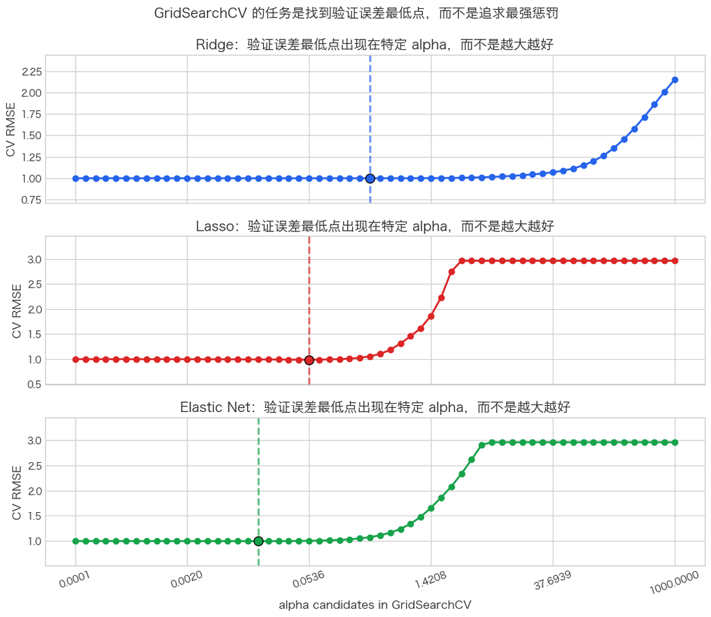

###### **本幕辅图（可选）**：最终模型对比结果表

如果保留，这张辅图只做总结：

- 哪个模型更偏向稳定预测；
- 哪个模型更偏向变量筛选；
- 哪个模型在相关变量场景下更稳健。

| model | best_alpha | best_cv_rmse | nonzero_coef | how_to_read |
| --- | --- | --- | --- | --- |
| Lasso | 0.053600 | 0.986600 | 4 | 更偏变量筛选 / 稀疏结果 |
| Elastic Net | 0.013700 | 0.995700 | 6 | 相关变量成组时更稳健 |
| Ridge | 0.275900 | 0.996800 | 6 | 更偏稳定预测 / 抗共线性 |

这一幕要收住两个判断：

- `alpha` 不能靠肉眼挑，而要通过交叉验证来选；
- 最稀疏不一定最好，最强惩罚也不一定最好。

## 第六幕：变量选择

到这里，一个自然的问题会冒出来： **如果我就是想要一份“变量名单”，除了 Lasso 这种正则化方法，还有没有更经典、更直接的选法？**

这一幕专门引入：

- 前向选择（forward selection）
- 后向剔除（backward elimination）
- 双向逐步回归（stepwise selection）

它们不是本周的主角，但这里需要知道： **变量选择并不只有 Lasso 一条路。**

如果老板说：“我不要 20 个变量，我只要 4 个。”

你觉得更自然的做法是哪一种？

1. 一个一个加进去，看谁能提升评价表现；
2. 从全模型开始，一个一个删掉表现最不关键的变量；
3. 直接让 Lasso 自动压成 0。

这三种思路，你觉得分别会有什么优点和代价？

**本幕主图 1**：前向选择 vs 后向剔除 的变量进入/退出路径

这张图要回答：

> 如果目标就是得到一份更短的变量名单，前向/后向选择是怎么工作的？

课堂重点：

- 前向选择：从空模型出发，一次加入一个最有帮助的变量；
- 后向剔除：从全模型出发，一次删除一个最不关键的变量；
- 两条路径可能不同，最后名单也可能不同。

先看“路径”，不要急着背定义。

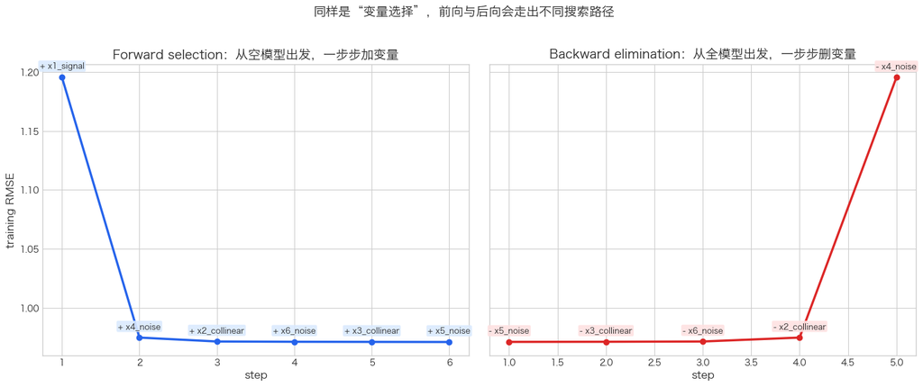

**本幕主图 2**：Lasso / 前向选择 / 后向剔除 的最终变量名单对比

这张图要回答：

> 不同变量选择方法，最后给出的名单会一样吗？

课堂重点：

- 变量选择结果依赖方法；
- 方法越贪心，越可能受当前路径影响；
- 稀疏结果很有吸引力，但它并不是唯一答案。

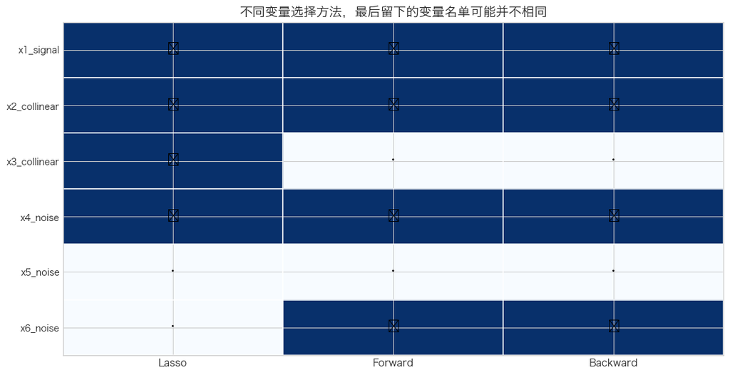

### 变量选择方法怎么做？先看它们在追什么

**标准看什么？**

- 在今天这个 notebook 里，为了把机制讲清，我们用的是误差表现（这里用 RMSE）来比较；
- 在更完整的建模流程里，也可以看交叉验证误差、AIC/BIC、调整后 `R^2`，或者结合业务可解释性要求；
- 关键不是死记某一个指标，而是先明确：你是在追求预测表现，还是追求更短、更可讲的变量名单。

**前向选择（Forward Selection）**

- **怎么做**：从空模型开始，每一步加入一个最能改善评价指标的变量；
- **优点**：直观、容易讲清“变量是怎么一步步进来的”；当变量很多时，通常比穷举更省；
- **劣势**：一旦前面加错，后面路径就会被带偏；已经加入的变量通常不容易被重新审视。

### 变量选择方法怎么做？再看删法与折中法

**后向剔除（Backward Elimination）**

- **怎么做**：从全模型开始，每一步删掉一个最不伤害评价指标的变量；
- **优点**：一开始看的是“完整信息”，适合在变量数不太大时做精简；
- **劣势**：变量很多时计算成本会高；如果变量间高度相关，删谁留谁可能会很敏感。

### 双向逐步回归怎么理解

**双向逐步回归（Stepwise Selection）**

- **怎么做**：可以看作“前向 + 后向”的折中版；
- **初始状态**：通常从空模型开始（也可以从一个较小的初始模型开始）；
- **迭代状态**：每一轮先尝试加入一个最有帮助的新变量，再检查当前模型里是否有变量应该被删掉；
- **终止状态**：当继续加入或删除都不能再明显改善评价指标时停止；
- **优点**：比纯前向更灵活，因为“加进来以后也允许后悔”；
- **劣势**：本质上仍然是逐步搜索，所以仍受评价标准、变量相关性和路径依赖影响，结果也不一定稳定。

这一幕要收住四个判断：

- 变量选择不只有 `Lasso`，还可以有前向选择、后向剔除等经典做法；
- 前向/后向/双向方法的优点是直观、名单感强，适合讲“怎么一步步选”；
- 它们的代价是路径依赖、计算代价上升，而且结果可能不稳定；
- 所以变量选择是“建模策略选择”，不是自动抽取真理。

## Synthesis 2

到这里，可以把三种方法压缩成一个判断框架：

- 想要稳定收缩、抗共线性：想到 `Ridge`；
- 想要稀疏结果、自动筛选：想到 `Lasso`；
- 遇到相关变量成组、又想筛选又想稳：想到 `Elastic Net`；
- 最后到底选哪个，不靠直觉，而要回到交叉验证结果；
- 而即便变量被选中了，也不自动等于“它拥有因果解释地位”。

## Transition

现在我们已经知道：

- 模型不能只看训练集拟合；
- penalty 会改变模型性格；
- 最终还要靠验证结果来选模型。

那下一步，一个模型到底该怎样被更系统地比较？

这会自然引向后续更系统的模型评估与模型选择问题。